# GET00203 - Estatística Computacional 1

Aula 12 - Testes de hipóteses para a média e proporção

[Rafael Erbisti](https://sites.google.com/site/rerbisti)

### Teste de Hipóteses para Média de uma distribuição normal com variância conhecida

Sejam $X \sim N(\mu, \sigma^2)$, com $\sigma^2$ conhecida, e $X_1, \ldots, X_n$ é uma amostra aleatória simples (a.a.s.) de $X$.

1. Suponha que queremos testar a hipótese nula simples:  
   $H_0 : \mu = \mu_0$  
   a um nível de significância $\alpha$.
2. A estatística de teste neste caso é a média amostral $\bar{X}$ e, como $\sigma^2$ é conhecida, sabemos que
   $$\bar{X} \sim N\left(\mu, \frac{\sigma^2}{n}\right).$$
3. Regra de decisão: rejeitar $H_0$ se $\bar{X}$ estiver longe do valor $\mu_0$.

##### Hipótese alternativa bilateral

A hipótese alternativa é:
$$H_1 : \mu \neq \mu_0$$
Neste caso, “estar longe” significa ser muito maior ou muito menor que $\mu_0$.

##### Região Crítica

Rejeitamos $H_0$ se:
$$\bar{X} > \mu_0 + k \quad \text{ou} \quad \bar{X} < \mu_0 - k$$

A probabilidade de cometer um erro tipo I é dada por:

$$P(\text{erro tipo I}) = P(\text{rejeitar } H_0 \mid H_0 \text{
verdadeira})$$

Assim, temos que:

$$\alpha = P(\bar{X} > \mu_0 + k \quad \text{ou} \quad \bar{X} <
\mu_0 - k \mid \mu = \mu_0)$$

Sabemos que:

$$\alpha = P\left(\bar{X} > \mu_0 + k \quad \text{ou} \quad \bar{X}
< \mu_0 - k \;\middle|\; \bar{X} \sim N\left(\mu_0,
\frac{\sigma^2}{n}\right)\right)$$

Logo, resolvendo para $k$, obtemos:

$$k = \dfrac{\sigma}{\sqrt{n}} z_{1 - \frac{\alpha}{2}}$$

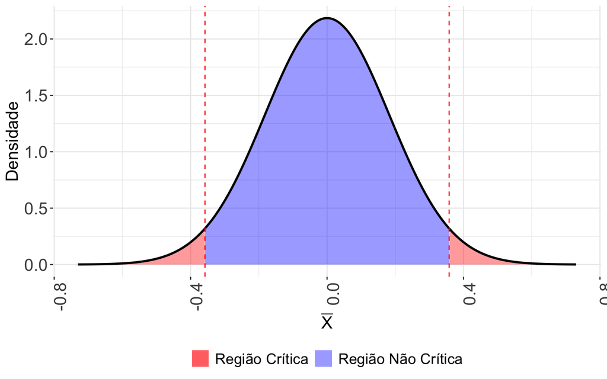

```r
# Parâmetros
mu0 = 0        # Média nula
sigma = 1      # Desvio padrão
n = 30         # Tamanho da amostra
alpha = 0.05   # Nível de significância

# Estatística: k para o nível de significância
k = qnorm(1 - alpha / 2, mean = 0, sd = 1) * sigma / sqrt(n)

# Criando os dados para o gráfico
x = seq(mu0 - 4 * sigma / sqrt(n), mu0 + 4 * sigma / sqrt(n), length.out = 1000)
density = dnorm(x, mean = mu0, sd = sigma / sqrt(n))

# Definindo as regiões manualmente
critico_esq = data.frame(x = x[x < mu0 - k],
                         y = density[x < mu0 - k],
                         regiao = "Região Crítica")

critico_dir = data.frame(x = x[x > mu0 + k],
                         y = density[x > mu0 + k],
                         regiao = "Região Crítica")

no_critico = data.frame(x = x[x >= mu0 - k & x <= mu0 + k],
                          y = density[x >= mu0 - k & x <= mu0 + k],
                          regiao = "Região Não Crítica")

# Combinando as regiões
data = rbind(critico_esq, critico_dir, no_critico)

# Gráfico
ggplot() +
  geom_area(data = no_critico, aes(x = x, y = y, fill = regiao), alpha = 0.4) +
  geom_area(data = critico_esq, aes(x = x, y = y, fill = regiao), alpha = 0.4) +
  geom_area(data = critico_dir, aes(x = x, y = y, fill = regiao), alpha = 0.4) +
  geom_line(data = data.frame(x = x, y = density), aes(x = x, y = y), color = "black",
            linewidth = 1) +
  geom_vline(xintercept = c(mu0 - k, mu0 + k), linetype = "dashed", color = "red") +
  scale_fill_manual(values = c("Região Crítica" = "red", "Região Não Crítica" = "blue")) +
  labs(x = expression(bar(X)),
       y = "Densidade") +
  theme_bw() +
  theme(axis.text.x = element_text(size = 16, angle = 90, hjust = 1),
        axis.title.x = element_text(size = 16),
        axis.text.y = element_text(size = 16),
        axis.title.y = element_text(size = 16),
        panel.border = element_blank(),
        legend.position = "bottom",
        legend.title = element_blank(),
        legend.text = element_text(size = 14))
```

##### Hipótese alternativa unilateral à direita

A hipótese alternativa unilateral à direita é definida como:

$$H_1 : \mu > \mu_0$$

Neste caso, estar “longe” significa que $\bar{X}$ é significativamente maior que $\mu_0$.

##### Região Crítica

$$\bar{X} > \mu_0 + k$$

com

$$k = \dfrac{\sigma}{\sqrt{n}} z_{1 - \alpha}$$

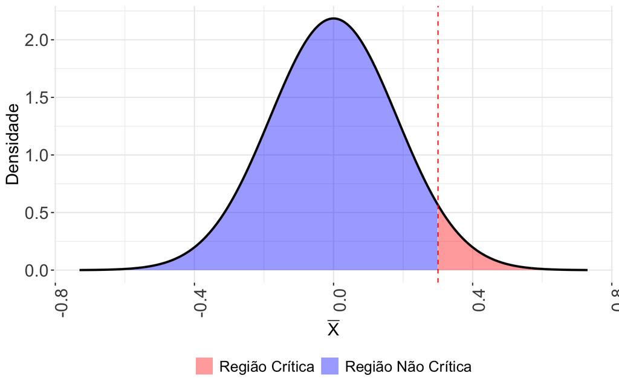

```r
# Parâmetros
mu0 = 0        # Média nula
sigma = 1      # Desvio padrão
n = 30         # Tamanho da amostra
alpha = 0.05   # Nível de significância

# Estatística: k para o nível de significância
k = qnorm(1 - alpha, mean = 0, sd = 1) * sigma / sqrt(n)

# Criando os dados para o gráfico
x = seq(mu0 - 4 * sigma / sqrt(n), mu0 + 4 * sigma / sqrt(n), length.out = 1000)
density = dnorm(x, mean = mu0, sd = sigma / sqrt(n))

# Definindo as regiões manualmente
critico_dir = data.frame(x = x[x > mu0 + k],
                         y = density[x > mu0 + k],
                         regiao = "Região Crítica")

no_critico = data.frame(x = x[x <= mu0 + k],
                          y = density[x <= mu0 + k],
                          regiao = "Região Não Crítica")

# Combinando as regiões
data = rbind(critico_dir, no_critico)

# Gráfico
ggplot() +
  geom_area(data = no_critico, aes(x = x, y = y, fill = regiao), alpha = 0.4) +
  geom_area(data = critico_dir, aes(x = x, y = y, fill = regiao), alpha = 0.4) +
  geom_line(data = data.frame(x = x, y = density), aes(x = x, y = y), color = "black", size = 1) +
  geom_vline(xintercept = mu0 + k, linetype = "dashed", color = "red") +
  scale_fill_manual(values = c("Região Crítica" = "red", "Região Não Crítica" = "blue")) +
  labs(x = expression(bar(X)),
       y = "Densidade") +
  theme_bw() +
  theme(axis.text.x = element_text(size = 16, angle = 90, hjust = 1),
        axis.title.x = element_text(size = 16),
        axis.text.y = element_text(size = 16),
        axis.title.y = element_text(size = 16),
        panel.border = element_blank(),
        legend.position = "bottom",
        legend.title = element_blank(),
        legend.text = element_text(size = 14))
```

##### Hipótese alternativa unilateral à esquerda

A hipótese alternativa unilateral à esquerda é definida como:

$$H_1 : \mu < \mu_0$$

Neste caso, estar “longe” significa que $\bar{X}$ é significativamente menor que $\mu_0$.

##### Região Crítica

$$k = \dfrac{\sigma}{\sqrt{n}} z_{1 - \alpha}$$

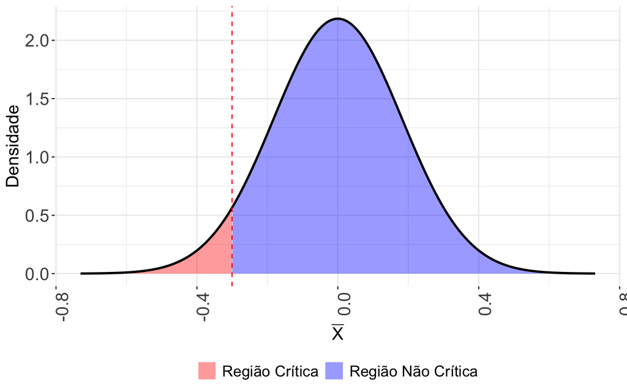

```r
# Parâmetros
mu0 = 0        # Média nula
sigma = 1      # Desvio padrão
n = 30         # Tamanho da amostra
alpha = 0.05   # Nível de significância

# Estatística: k para o nível de significância
k = qnorm(1 - alpha, mean = 0, sd = 1) * sigma / sqrt(n)

# Criando os dados para o gráfico
x = seq(mu0 - 4 * sigma / sqrt(n), mu0 + 4 * sigma / sqrt(n), length.out = 1000)
density = dnorm(x, mean = mu0, sd = sigma / sqrt(n))

# Definindo as regiões manualmente
critico_esq = data.frame(x = x[x < mu0 - k],
                         y = density[x < mu0 - k],
                         regiao = "Região Crítica")

no_critico = data.frame(x = x[x >= mu0 - k],
                        y = density[x >= mu0 - k],
                        regiao = "Região Não Crítica")

# Combinando as regiões
data = rbind(critico_esq, no_critico)

# Gráfico
ggplot() +
  geom_area(data = no_critico, aes(x = x, y = y, fill = regiao), alpha = 0.4) +
  geom_area(data = critico_esq, aes(x = x, y = y, fill = regiao), alpha = 0.4) +
  geom_line(data = data.frame(x = x, y = density), aes(x = x, y = y), color = "black", size = 1) +
  geom_vline(xintercept = mu0 - k, linetype = "dashed", color = "red") +
  scale_fill_manual(values = c("Região Crítica" = "red", "Região Não Crítica" = "blue")) +
  labs(x = expression(bar(X)),
       y = "Densidade") +
  theme_bw() +
  theme(axis.text.x = element_text(size = 16, angle = 90, hjust = 1),
        axis.title.x = element_text(size = 16),
        axis.text.y = element_text(size = 16),
        axis.title.y = element_text(size = 16),
        panel.border = element_blank(),
        legend.position = "bottom",
        legend.title = element_blank(),
        legend.text = element_text(size = 14))
```

#### p-valor

Existem duas opções para expressar a conclusão final de um teste de hipóteses:

1. Comparar o valor da estatística do teste com o valor obtido a partir da distribuição teórica específica para o teste, considerando um nível de significância pré-fixado.  
   Este procedimento é baseado na construção da **região crítica**, como descrito no procedimento geral.
2. Quantificar a probabilidade do que foi observado, ou resultados mais extremos, assumindo que a hipótese nula $H_0$ é verdadeira.  
   Esse valor é conhecido como o **p-valor**.

O **p-valor** ou **valor-p** representa a probabilidade de um valor da estatística de teste que seja tão ou mais extremo do que o observado na amostra, sob a hipótese de que $H_0$ é verdadeira. Formalmente, podemos escrever:

$$\text{p-valor} = P(T \geq t \mid H_0 \text{ verdadeira})$$

Como o p-valor é calculado supondo-se que $H_0$ é verdadeira, podem-se fazer duas conjecturas quando se obtém um valor muito pequeno:

1. Um evento extremamente raro pode ter ocorrido; ou
2. A hipótese $H_0$ não deve ser verdadeira, ou seja, a conjectura inicial e conservadora não parece plausível.

**Quanto menor o p-valor, maior é a evidência para se rejeitar $H_0$.**

#### Exemplo

Uma fábrica deseja verificar se o peso médio de seus produtos excede o valor especificado de $\mu_0 = 50$ gramas. Sabe-se que o desvio-padrão populacional do peso dos produtos é 10 gramas, e o tamanho das 100 amostras coletadas para o teste é de 30 unidades.

Para cada uma das amostras avalie a conclusão do teste de hipótese ao nível de significância de 5%.

###### Hipóteses

$H_0: \mu = \mu_0$ *x* $H_1: \mu > \mu_0$

```r
set.seed(42)

# Parâmetros da população
mu0 = 50                   # Média sob H0
sigma = 10                 # Desvio padrão
n = 30                     # Tamanho da amostra
alpha = 0.05               # Nível de significância

# Número de amostras simuladas
n_amostras = 100

# Simulando 100 amostras de tamanho 30
amostras = replicate(n_amostras, rnorm(n, mean = mu0, sd = sigma))
amostras[1:5,1:10]
```

```
         [,1]     [,2]     [,3]     [,4]     [,5]     [,6]     [,7]     [,8]
[1,] 63.70958 54.55450 46.32765 63.92116 35.06375 49.59302 51.51456 37.98778
[2,] 44.35302 57.04837 51.85231 45.23826 35.29564 34.48455 44.15891 70.36972
[3,] 53.63128 60.35104 55.81824 56.50349 51.24702 61.67170 53.68807 51.07775
[4,] 56.32863 43.91074 63.99737 63.91110 40.03361 47.26354 52.94654 49.15892
[5,] 54.04268 55.04955 42.72708 38.89211 49.98177 45.32155 47.20741 54.95620
         [,9]    [,10]
[1,] 42.70783 55.73752
[2,] 59.98069 50.45804
[3,] 62.58482 51.57413
[4,] 62.48864 54.31565
[5,] 36.19363 46.03450
```

```r
# Estatísticas das 100 amostras
amostra_media = colMeans(amostras)  # Médias amostrais
amostra_media
```

```
 [1] 50.68587 48.78091 51.90769 49.81160 47.37690 49.83181 48.58792 49.92803
 [9] 49.88406 51.02730 49.79879 48.89457 51.69023 48.44746 50.27647 49.75522
[17] 47.90026 51.14561 50.87402 48.46635 51.59670 48.06340 49.87675 46.26971
[25] 49.10136 48.21113 48.93799 47.79996 50.26532 53.39162 49.99938 49.69176
[33] 52.65372 49.03435 48.64260 49.13663 49.27576 51.32734 50.45335 49.61950
[41] 50.85952 50.39159 50.26979 50.95801 47.81255 48.34708 48.77032 49.76239
[49] 48.44372 50.44639 50.41837 47.51753 52.41709 52.37032 52.03355 51.65558
[57] 54.50499 47.36947 49.24153 48.06233 51.05067 51.91582 52.48778 49.15696
[65] 44.85350 51.39925 46.74988 53.49452 49.68848 47.56267 48.62583 51.14836
[73] 50.56235 48.17517 49.82459
 [ reached getOption("max.print") -- omitted 25 entries ]
```

```r
amostra_sd = sigma / sqrt(n)        # Erro padrão conhecido
amostra_sd
```

```
[1] 1.825742
```

```r
# Valor crítico (unilateral à direita, H1: mu > mu0)
z_alpha = qnorm(1 - alpha)
z_alpha
```

```
[1] 1.644854
```

```r
valor_critico = mu0 + z_alpha * amostra_sd
valor_critico
```

```
[1] 53.00308
```

```r
# p-valores para cada amostra
p_valores = pnorm(amostra_media, mean = mu0, sd = amostra_sd, lower.tail = FALSE)
p_valores
```

```
 [1] 0.353582770 0.747843944 0.148037788 0.541093700 0.924602998 0.536699628
 [7] 0.780365700 0.515721416 0.525317398 0.286827163 0.543876709 0.727565556
[13] 0.177280331 0.802437798 0.439819212 0.553327577 0.874943657 0.265174136
[19] 0.316068391 0.799550166 0.190910032 0.855591912 0.526909851 0.979482004
[25] 0.688712980 0.836408582 0.719610764 0.885900403 0.442228215 0.031608034
[31] 0.500134819 0.567034431 0.073042324 0.701565380 0.771404662 0.681852752
[37] 0.654199343 0.233609403 0.401946514 0.582545381 0.318899239 0.415085064
[43] 0.441261466 0.299886997 0.884564386 0.817357875 0.749693461 0.551774417
[49] 0.803007221 0.403422461 0.409376017 0.913038489 0.092769058 0.097095961
[55] 0.132677560 0.182257267 0.006803292 0.925179789 0.661086669 0.855724719
[61] 0.282485240 0.147010728 0.086502569 0.677871365 0.997590234 0.221718565
[67] 0.962475470 0.027808244 0.567740236 0.909058956 0.774174148 0.264679372
[73] 0.379037290 0.841224216 0.538270946
 [ reached getOption("max.print") -- omitted 25 entries ]
```

```r
# Conclusão para cada teste
conclusao = ifelse(p_valores < alpha, "Rejeita H0", "Não Rejeita H0")

# Resultados resumidos
resultados = data.frame(Média_Amostral = amostra_media,
                        p_valor = p_valores,
                        Conclusão = conclusao)
head(resultados,10)
```

```
   Média_Amostral   p_valor      Conclusão
1        50.68587 0.3535828 Não Rejeita H0
2        48.78091 0.7478439 Não Rejeita H0
3        51.90769 0.1480378 Não Rejeita H0
4        49.81160 0.5410937 Não Rejeita H0
5        47.37690 0.9246030 Não Rejeita H0
6        49.83181 0.5366996 Não Rejeita H0
7        48.58792 0.7803657 Não Rejeita H0
8        49.92803 0.5157214 Não Rejeita H0
9        49.88406 0.5253174 Não Rejeita H0
10       51.02730 0.2868272 Não Rejeita H0
```

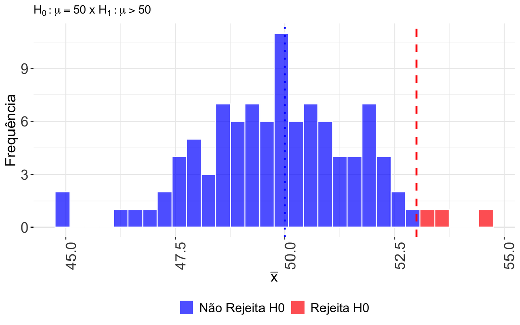

```r
# Visualizando as conclusões para cada amostra gerada
ggplot(resultados, aes(x = Média_Amostral)) +
  geom_histogram(aes(fill = Conclusão), bins = 30, color = "white", alpha = 0.7) +
  geom_vline(xintercept = valor_critico, linetype = "dashed", color = "red", size = 1) +
  geom_vline(xintercept = mu0, linetype = "dotted", color = "blue", size = 1) +
  labs(title = expression(H[0]: mu == 50 ~ "x" ~ H[1]: mu > 50),
       x = expression(bar(x)),
       y = "Frequência") +
  scale_fill_manual(values = c("Rejeita H0" = "red", "Não Rejeita H0" = "blue")) +
  theme_bw() +
  theme(axis.text.x = element_text(size = 16, angle = 90, hjust = 1),
        axis.title.x = element_text(size = 16),
        axis.text.y = element_text(size = 16),
        axis.title.y = element_text(size = 16),
        panel.border = element_blank(),
        legend.position = "bottom",
        legend.title = element_blank(),
        legend.text = element_text(size = 14))
```

#### Teste de Hipóteses para a Média de uma distribuição normal com variância desconhecida

Sejam $X \sim N(\mu, \sigma^2)$, com $\sigma^2$ desconhecida, e $X_1, \dots, X_n$ uma amostra aleatória simples (a.a.s.) de $X$.

1. Suponha que queremos testar a hipótese nula simples:
   $$H_0 : \mu = \mu_0$$
   ao nível de significância $\alpha$.
2. A estatística de teste neste caso é a média amostral $\bar{X}$. Como $\sigma^2$ é desconhecido, sabemos que:
   $$\dfrac{\bar{X}-\mu}{\sqrt{S^2/n}} \sim t_{n-1}$$
3. **Regra de decisão:** Rejeitar $H_0$ se $\bar{X}$ estiver longe do valor $\mu_0$.

**Note que o procedimento será o mesmo que no caso da variância conhecida, exceto pela distribuição amostral de $\dfrac{\bar{X}-\mu}{\sqrt{S^2/n}}$, que agora segue uma distribuição $t$ com $n-1$ graus de liberdade.**

Supondo um nível de significância $\alpha$, os testes podem ser definidos da seguinte forma:

##### Teste Bilateral: $H_1 : \mu \neq \mu_0$

- **Região Crítica:**
  $$\bar{X} > \mu_0 + k \quad \text{ou} \quad \bar{X} < \mu_0 - k$$
  onde:
  $$k = \frac{S}{\sqrt{n}} t_{n-1, 1 - \frac{\alpha}{2}}$$
- **p-valor:**
  $$p\text{-valor} = 2P\left( \bar{X} > \bar{x}
  \,\middle|\, \dfrac{\bar{X}-\mu_0}{\sqrt{S^2/n}} \sim t_{n-1}\right)$$

##### Teste Unilateral à Direita: $H_1 : \mu > \mu_0$

- **Região Crítica:**
  $$\bar{X} > \mu_0 + k$$
  onde:
  $$k = \frac{S}{\sqrt{n}} t_{n-1, 1 - \alpha}$$
- **p-valor:**
  $$p\text{-valor} = P\left( \bar{X} > \bar{x}
  \,\middle|\, \dfrac{\bar{X}-\mu_0}{\sqrt{S^2/n}} \sim t_{n-1} \right)$$

##### Notação

- $\bar{X}$: estatística.
- $\bar{x}$: valor observado da média amostral.
- $S$: desvio padrão amostral.
- $t_{n-1, \cdots}$: quantil da distribuição $t$ de Student com $n-1$ graus de liberdade.
- $n$: tamanho da amostra.
- $\alpha$: nível de significância.

#### Exemplo

Uma empresa deseja verificar se o peso médio de seus pacotes está de acordo com a especificação do fabricante de $\mu = 30$ gramas. Foram coletadas 200 amostras com 25 unidades para testar se o peso médio dos pacotes está de acordo com a especificação.

###### Hipóteses

$H_0: \mu = \mu_0$ *x* $H_1: \mu \neq \mu_0$

```r
set.seed(42)

# Parâmetros da população
mu0 = 30                   # Média sob H0
n = 25                     # Tamanho da amostra
alpha = 0.05               # Nível de significância

# Número de amostras simuladas
n_amostras = 200

# Simulando 100 amostras de tamanho 25
# (o sigma precisou ser fixo para simular as amostrar)
amostras = replicate(n_amostras, rnorm(n, mean = mu0, sd = 10))

# Estatísticas das 200 amostras
amostra_media = colMeans(amostras)   # Médias amostrais
amostra_sd = apply(amostras, 2, sd)  # Desvio padrão amostral de cada amostra
erro_padrao = amostra_sd / sqrt(n)   # Erro padrão amostral

# Valor crítico para o teste bilateral (t de Student)
t_alpha = qt(1 - alpha / 2, df = n - 1)                 # Quantil da distribuição t

# Calculando o valor crítico para cada amostra
valor_critico_inferior = mu0 - t_alpha * erro_padrao  # Região inferior
valor_critico_superior = mu0 + t_alpha * erro_padrao  # Região superior

# p-valores para cada amostra
p_valores = 2 * pt(abs(amostra_media - mu0) / erro_padrao, df = n - 1, lower.tail = FALSE)

# Conclusão para cada teste
conclusao = ifelse(p_valores < alpha, "Rejeita H0", "Não Rejeita H0")

# Resultados resumidos
resultados = data.frame(Média_Amostral = amostra_media,
                        p_valor = p_valores,
                        Conclusão = conclusao,
                        Valor_Critico_Inf = valor_critico_inferior,
                        Valor_Critico_Sup = valor_critico_superior)
head(resultados, 10)
```

```
   Média_Amostral   p_valor      Conclusão Valor_Critico_Inf Valor_Critico_Sup
1        31.87536 0.4798228 Não Rejeita H0          24.60759          35.39241
2        27.41120 0.1843076 Não Rejeita H0          26.09131          33.90869
3        31.42743 0.4695465 Não Rejeita H0          25.99097          34.00903
4        30.58660 0.7457961 Não Rejeita H0          26.30828          33.69172
5        28.58757 0.4990247 Não Rejeita H0          25.75320          34.24680
6        28.38740 0.3441031 Não Rejeita H0          26.55153          33.44847
7        29.99014 0.9958716 Não Rejeita H0          26.10944          33.89056
8        29.53553 0.7851009 Não Rejeita H0          26.52358          33.47642
9        28.62164 0.5154244 Não Rejeita H0          25.69090          34.30910
10       31.53715 0.4153582 Não Rejeita H0          26.17236          33.82764
```

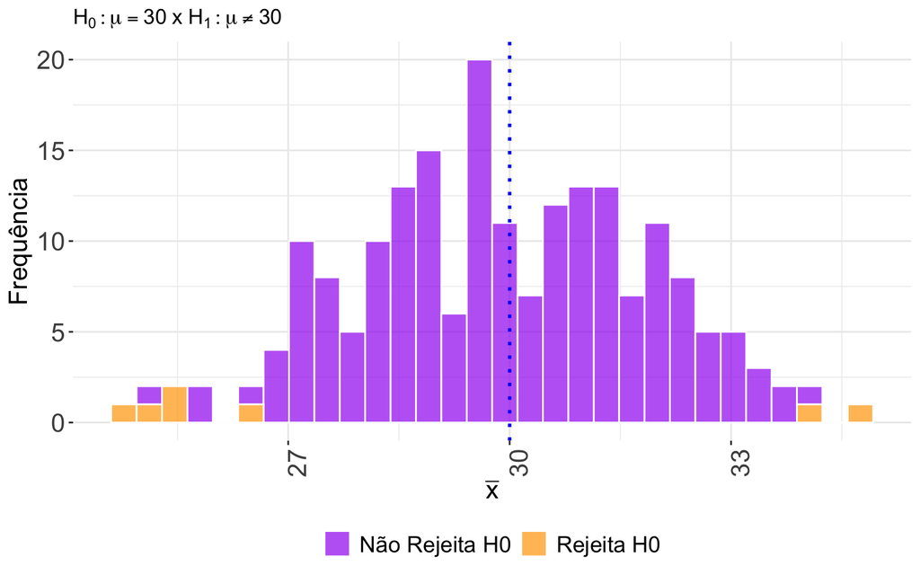

```r
# Visualizando as conclusões para cada amostra gerada
ggplot(resultados, aes(x = Média_Amostral)) +
  geom_histogram(aes(fill = Conclusão), bins = 30, color = "white", alpha = 0.7) +
  geom_vline(xintercept = mu0, linetype = "dotted", color = "blue", size = 1) +
  labs(title = expression(H[0]: mu == 30 ~ "x" ~ H[1]: mu != 30),
       x = expression(bar(x)),
       y = "Frequência") +
  scale_fill_manual(values = c("Rejeita H0" = "orange", "Não Rejeita H0" = "purple")) +
  theme_bw() +
  theme(axis.text.x = element_text(size = 16, angle = 90, hjust = 1),
        axis.title.x = element_text(size = 16),
        axis.text.y = element_text(size = 16),
        axis.title.y = element_text(size = 16),
        panel.border = element_blank(),
        legend.position = "bottom",
        legend.title = element_blank(),
        legend.text = element_text(size = 14))
```

#### Teste de Hipóteses para Proporção

Sejam $X \sim \text{Ber}(p)$, e $X_1, X_2, \dots, X_n$ uma amostra aleatória simples de $X$.

1. Suponha que queremos testar:

$$H_0 : p = p_0 \quad \text{x} \quad H_1 : p \neq p_0$$
ao nível de significância $\alpha$.

2. Usando o Teorema do Limite Central (TLC), tomamos a seguinte estatística de teste:

$$\hat{P} \dot\sim N \left( p_0, \frac{p_0(1-p_0)}{n} \right).$$

3. Regra de decisão: Rejeitar $H_0$ se $\hat{P}$ estiver longe do valor $p_0$.

Supondo um nível de significância $\alpha$:

##### Teste bilateral: $H_1 : p \neq p_0$

$$\hat{P} > p_0 + k \quad \text{ou} \quad \hat{P} < p_0 - k$$

onde

$$k = z_{1-\frac{\alpha}{2}} \sqrt{\frac{p_0(1-p_0)}{n}},$$

e o p-valor é dado por

$$p\text{-valor} = 2P\left( \hat{P} > \hat{p} \,\middle|\, \hat{P}
\dot\sim N\left(p_0, \frac{p_0(1-p_0)}{n}\right) \right).$$

##### Teste unilateral à direita: $H_1 : p > p_0$

$$\hat{P} > p_0 + k$$

onde

$$k = z_{1-\alpha} \sqrt{\frac{p_0(1-p_0)}{n}},$$

e o p-valor é dado por

$$p\text{-valor} = P\left( \hat{P} > \hat{p} \,\middle|\, \hat{P}
\dot\sim N\left(p_0, \frac{p_0(1-p_0)}{n}\right) \right).$$

##### Teste unilateral à esquerda: $H_1 : p < p_0$

$$\hat{P} < p_0 - k$$

onde

$$k = z_{1-\alpha} \sqrt{\frac{p_0(1-p_0)}{n}},$$

e o p-valor é dado por

$$p\text{-valor} = P\left( \hat{P} < \hat{p} \,\middle|\, \hat{P}
\dot\sim N\left(p_0, \frac{p_0(1-p_0)}{n}\right) \right).$$

#### Exemplo

A Doença X é uma condição que afeta, aproximadamente, 8% da população mundial. Estudos prévios sugerem que a prevalência dessa doença pode ser mais alta em determinadas faixas etárias ou regiões geográficas. Recentemente, foi realizado um estudo para determinar se a prevalência da Doença X em amostras de 1000 pessoas em 80 países é significativamente diferente da prevalência conhecida de 8% em nível global.

O objetivo deste estudo é testar se a prevalência da Doença X nesta população local é inferior à prevalência global de 8%, utilizando um nível de significância de 0,1.

- **Hipótese nula ($H_0$)**: A prevalência da Doença X nesta população é igual à prevalência global de 8%.

  $$H_0: p = 0,08$$
- **Hipótese alternativa ($H_1$)**: A prevalência da Doença X nesta população é inferior à prevalência global de 8%.

  $$H_1: p < 0,08$$

```r
# Parâmetros do estudo
p0 = 0.08                  # Proporção global da Doença X
n = 1000                   # Tamanho da amostra em cada país
alpha = 0.1                # Nível de significância

# Número de amostras (países)
n_paises = 80

# Simulando 80 amostras de tamanho 50 com prevalência p0
# Vamos supor que a prevalência da Doença X na amostra de cada país seja aleatória, mas com p0 médio
amostras = replicate(n_paises, rbinom(1, size = n, prob = p0))

# Proporções amostrais
amostra_proporcao = amostras / n  # Proporção de pessoas com a Doença X em cada país

# Erro padrão da proporção amostral
erro_padrao = sqrt(p0 * (1 - p0) / n)
erro_padrao
```

```
[1] 0.008579044
```

```r
# Valor crítico para o teste unilateral à esquerda
z_alpha = qnorm(1 - alpha)  # Quantil da normal padrão
z_alpha
```

```
[1] 1.281552
```

```r
# Calculando o valor crítico inferior para cada amostra
valor_critico = p0 - (z_alpha * erro_padrao)
valor_critico
```

```
[1] 0.06900551
```

```r
# p-valores para cada amostra
p_valores = pnorm(amostra_proporcao, mean = p0, sd = erro_padrao)

# Conclusão para cada teste
conclusao = ifelse(p_valores < alpha, "Rejeita H0", "Não Rejeita H0")

# Resultados resumidos
resultados = data.frame(Proporcao_Amostral = amostra_proporcao,
                        p_valor = p_valores,
                        Conclusao = conclusao)
head(resultados, 10)
```

```
   Proporcao_Amostral    p_valor      Conclusao
1               0.067 0.06484565     Rejeita H0
2               0.091 0.90011272 Não Rejeita H0
3               0.082 0.59216830 Não Rejeita H0
4               0.090 0.87811817 Não Rejeita H0
5               0.080 0.50000000 Não Rejeita H0
6               0.090 0.87811817 Não Rejeita H0
7               0.085 0.71999125 Não Rejeita H0
8               0.089 0.85292657 Não Rejeita H0
9               0.066 0.05135202     Rejeita H0
10              0.078 0.40783170 Não Rejeita H0
```

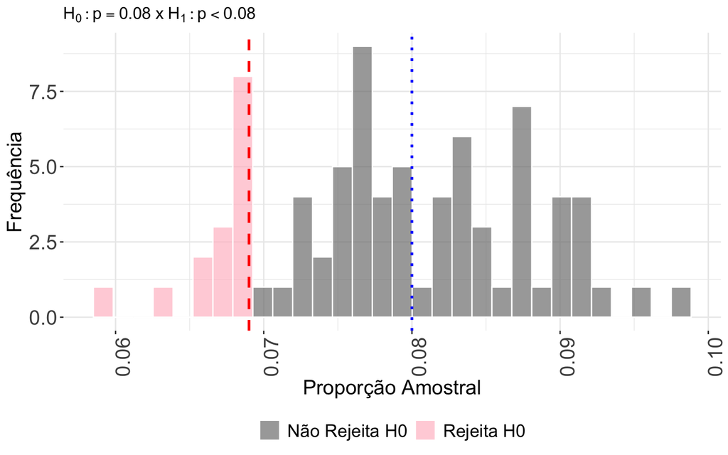

```r
# Visualizando as conclusões para cada amostra gerada
ggplot(resultados, aes(x = Proporcao_Amostral)) +
  geom_histogram(aes(fill = Conclusao), color = "white", alpha = 0.7) +
  geom_vline(xintercept = p0, linetype = "dotted", color = "blue", size = 1) +
  geom_vline(xintercept = valor_critico, linetype = "dashed", color = "red", size = 1) +
  labs(title = expression(H[0]: p == 0.08 ~ "x" ~ H[1]: p < 0.08),
       x = "Proporção Amostral",
       y = "Frequência") +
  scale_fill_manual(values = c("Rejeita H0" = "pink", "Não Rejeita H0" = "gray50")) +
  theme_bw() +
  theme(axis.text.x = element_text(size = 16, angle = 90, hjust = 1),
        axis.title.x = element_text(size = 16),
        axis.text.y = element_text(size = 16),
        axis.title.y = element_text(size = 16),
        panel.border = element_blank(),
        legend.position = "bottom",
        legend.title = element_blank(),
        legend.text = element_text(size = 14))
```